# Course Work 1 - FFT, Filtering and Spectrograms

# Tutorial Section

```python
# Importing all packages that we need.

# This is a package for handling and manipulating data.
import pandas as pd

# This is the standard package for plotting.
from matplotlib import pyplot as plt

# Seaborn is build on matplotlib.
# It is more comfortable to use than pure matplotlib.
import seaborn as sns

# Numpy helps us handling arrays of numbers
import numpy as np

# We use this function to calculate the fft
from numpy.fft import fft, ifft

# This shifts the output of the fft so that zero frequency is at the centre
from numpy.fft import fftshift

# The inverse of fftshift
from numpy.fft import ifftshift

import matplotlib as mpl
mpl.rcParams['figure.dpi'] = 100

from scipy import signal

from scipy.io import wavfile

import IPython.display as ipd
```

# Inverse FFT

I have so far only looked at the FFT, but not at its inverse that takes us from the frequency domain back to the time domain.

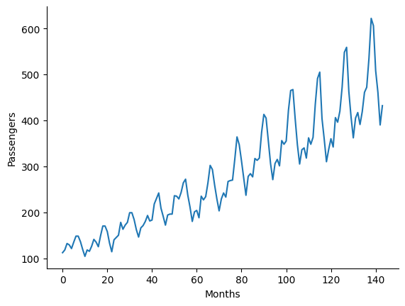

```python
# We will start again with the flight dataset
flights = sns.load_dataset("flights")
passengers = np.array(flights['passengers'])
months = np.arange(passengers.size)
sns.lineplot(x=months, y=passengers)
plt.xlabel('Months')
plt.ylabel('Passengers')
sns.despine()
```

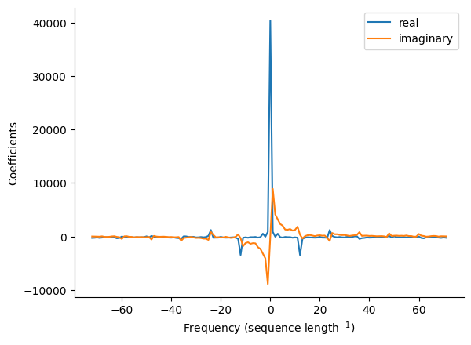

```python
# Applying the FFT
passengersFFT = fftshift(fft(passengers))

# Using this as x-axis to plot our coefficients against
freqs = np.arange(passengers.size)

# We know that zero frequency is in the centre, so we have to subtract half the length of the array
freqs = freqs - (passengers.size)//2

# Plotting the results again
sns.lineplot(x=freqs, y=passengersFFT.real, label = 'real')
sns.lineplot(x=freqs, y=passengersFFT.imag, label = 'imaginary')
plt.ylabel('Coefficients')
# The x-axis now corresponds to the frequency as repetitions per sequence length
plt.xlabel('Frequency (sequence length$^{-1}$)')
plt.legend()
sns.despine()
plt.show()
```

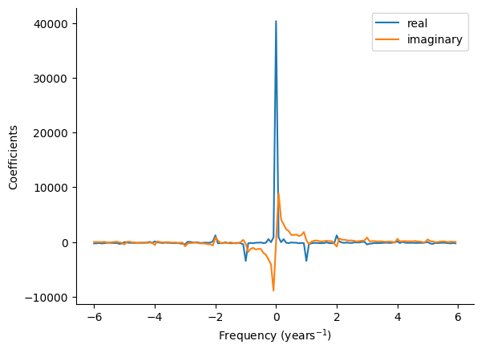

```python
# We have 12 years in the time series.
freqsYears = freqs/12.0

# Plotting the results again
sns.lineplot(x=freqsYears, y=passengersFFT.real, label = 'real')
sns.lineplot(x=freqsYears, y=passengersFFT.imag, label = 'imaginary')
plt.ylabel('Coefficients')
# The x-axis now correspods to the frequency as repetitions per sequence length
plt.xlabel('Frequency (years$^{-1}$)')
plt.legend()
sns.despine()
```

Applying the inverse FFT:

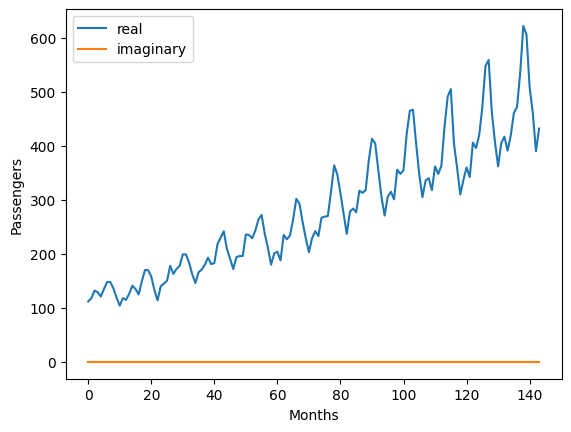

```python
#Having to first apply the inverse fftshift
passengersFFT_shotfBack = ifftshift(passengersFFT)

#Apllying the inverse FFT
passangers_reconstructed = ifft(passengersFFT_shotfBack)

# Results:Note that the result is complex.

plt.plot(passangers_reconstructed.real, label ='real')
plt.plot(passangers_reconstructed.imag, label = 'imaginary')
plt.legend()
plt.xlabel('Months')
plt.ylabel('Passengers')
plt.show()

# Taking only the real part
# The imaginary part is zero (up to numerical accuracy)
passangers_reconstructed = passangers_reconstructed.real
```

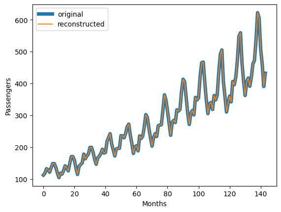

```python
# The reconstrutcion is identical to the original
plt.plot(flights['passengers'], label ='original', linewidth = 5)
plt.plot(passangers_reconstructed, label = 'reconstructed')
plt.legend()
plt.xlabel('Months')
plt.ylabel('Passengers')
plt.show()
```

## Filtering in Frequency Space

Applying a filter, before we reconstruct the signal. This way, we can amplify or remove frequencies. Before we build a filter, we will make a plot of the spectrum.

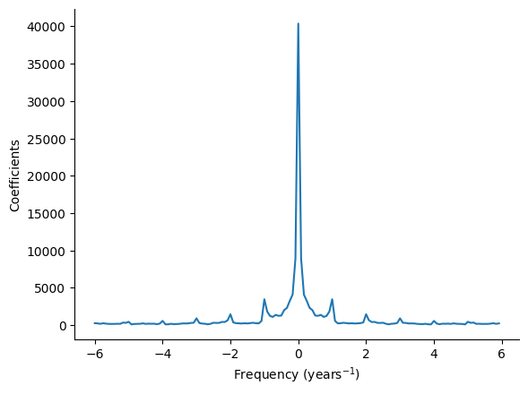

```python
# We apply the FFT
passengersFFT = fftshift(fft(passengers))

# We will use this as x-axis to plot our coefficients against
freqs = np.arange(passengers.size)

# We know that zero frequency is in the centre, so we have to subtract half the length of the array
freqs = freqs - (passengers.size)//2

# We have 12 years in the time series.
freqsYears = freqs/12.0

# Plotting the results again
sns.lineplot(x = freqsYears, y = np.abs(passengersFFT))
plt.ylabel('Coefficients')
# The x-axis now correspods to the frequency as repetitions per sequence length
plt.xlabel('Frequency (years$^{-1}$)')
sns.despine()
```

Building a filter and plot the filter weights:

## Important: to do this correctly, we have to keep also the negative frequencies and treat them in the same way as the corresponding positive ones.

Thus, the filter has to extend also to the negative part.

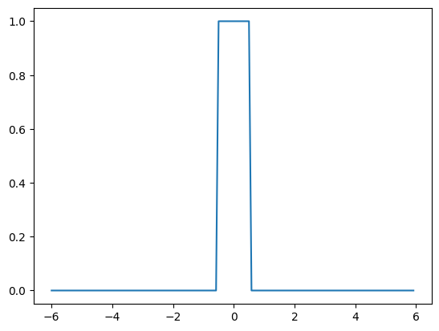

```python
# We are building a brickwall filter that
# will remove all frequencies above 0.5 years^-1
maxf = 0.5

# We start with an array of ones
weights = np.ones(len(freqsYears))

# This will set all the frequencies we want to keep to 0
weights[(freqsYears>maxf)] = 0.0

# We also have to consider the negative frequencies
weights[(freqsYears<-maxf)] = 0.0

# Plotting the filter
plt.plot(freqsYears, weights)
```

Applying the filter:

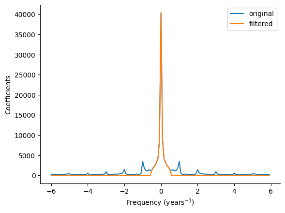

```python
#multiplying the filter
passengersFFT_filtered = passengersFFT*weights

#Look at the resulting spectrum
sns.lineplot(x = freqsYears, y = np.abs(passengersFFT), label = 'original')
sns.lineplot(x = freqsYears, y = np.abs(passengersFFT_filtered), label = 'filtered')
plt.ylabel('Coefficients')
# The x-axis now correspods to the frequency as repetitions per sequence length
plt.xlabel('Frequency (years$^{-1}$)')
sns.despine()
plt.legend()
```

Look at the reconstructed filtered time series.

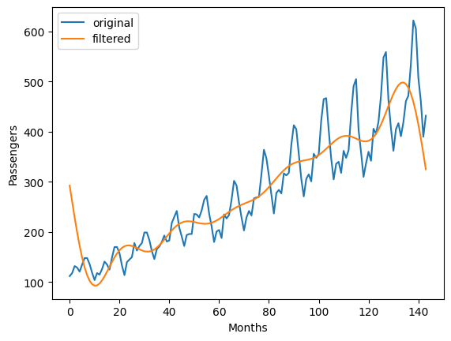

```python
# first applying the inverse fftshift
passengersFFT_shotfBack = ifftshift(passengersFFT_filtered)

#applying the inverse FFT
passangers_reconstructed = ifft(passengersFFT_shotfBack)

# We only need the real part
# The imaginary part is zero (up to numerical accuracy)
passangers_reconstructed = passangers_reconstructed.real

# The our reconstrutcion is identical to the original
plt.plot(flights['passengers'], label ='original')
plt.plot(passangers_reconstructed, label = 'filtered')
plt.legend()
plt.xlabel('Months')
plt.ylabel('Passengers')
plt.show()
```

## Loading Audio Samples

```python
# we load the wav file
sample_rate, data = wavfile.read("Jungle-SoundBible.com-1211567897.wav")
# we get the sample rate (number of samples per second)
# and the data itself. It is stereo, i.e., has two channels.
print(sample_rate, data.shape)

# we use only one of the channels
data = data[:,0]
```

```
22050 (119808, 2)
```

```python
# Plotting the time series
```

```python
#Printing some stats
number_of_samples = len(data)
length_in_seconds = len(data)/sample_rate
print("number of samples:", number_of_samples)
print("length is seconds:", length_in_seconds)
print("samples per second:", sample_rate)

# We can use this to play the file
ipd.Audio(data, rate = sample_rate ) # load a local WAV file
```

```
number of samples: 119808
length is seconds: 5.433469387755102
samples per second: 22050
```

[interactive chart not shown]

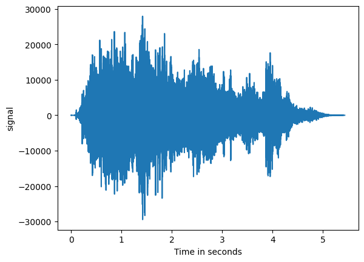

```python
#Plotting the signal
# To get the x-axis in seconds
x = np.arange(number_of_samples) / sample_rate
plt.plot(x, data)
plt.xlabel('Time in seconds')
plt.ylabel('signal')
```

## Spectrograms

We can create a spectrogram by using the spectrogram function provided by [scipy](https://docs.scipy.org/doc/scipy/reference/generated/scipy.signal.spectrogram.html).

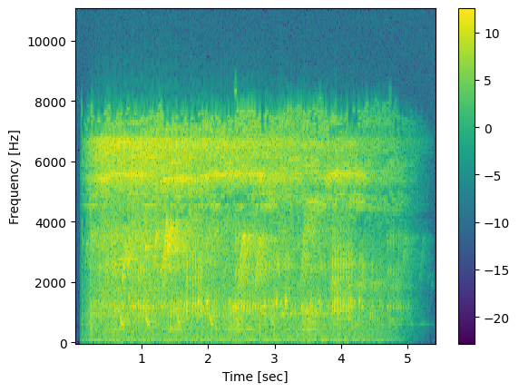

```python
f, t, Sxx = signal.spectrogram(data, sample_rate)

# note that we use the logarithm before visualisation
plt.pcolormesh(t, f, np.log(Sxx))
plt.ylabel('Frequency [Hz]')

plt.xlabel('Time [sec]')

plt.colorbar()

plt.show()
```

Modifying the spectrogram:

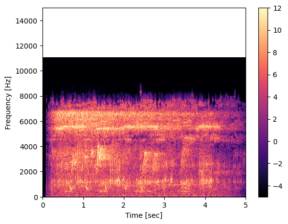

```python
f, t, Sxx = signal.spectrogram(data, sample_rate)

# we can use a different colour map by setting cmap
# can choose the minimum and maximum by choosing vmin, vmax
plt.pcolormesh(t, f, np.log(Sxx), cmap = 'magma', vmin = -5, vmax = 12)

# we can choose to look only at a limited region
plt.ylabel('Frequency [Hz]')

plt.xlabel('Time [sec]')

plt.ylim(0,15000)
plt.xlim(0,5)

plt.colorbar()

plt.show()
```

# Exercises

## Exercise 1 (2 marks)

Load the file './Jungle-SoundBible.com-1211567897.wav' you can disregard one of the channels. Print the number of samples, the length of the file in seconds, and the sample rate. Listen to the file and and plot the **time series**, **the spectrum**, and **the spectrogram**. Make sure that the axes are labeled in a sensible way.

```python
# Please implement
s_rate, a = wavfile.read('Jungle-SoundBible.com-1211567897.wav')
print(s_rate, a.shape)

a = a[:,0]
number_of_samples = len(a)
length_in_seconds = len(a)/s_rate
print("number of samples:", number_of_samples)
print("length is seconds:", length_in_seconds)
print("samples rate:", s_rate)

# We can use this to play the file
ipd.Audio(a, rate = s_rate ) # load a local WAV file
```

```
22050 (119808, 2)
number of samples: 119808
length is seconds: 5.433469387755102
samples rate: 22050
```

[interactive chart not shown]

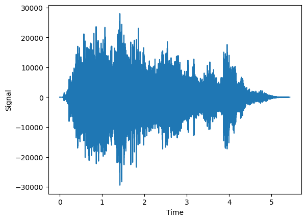

```python
x1 = np.arange(number_of_samples) / s_rate
plt.plot(x1,a)
plt.xlabel("Time")
plt.ylabel("Signal")
```

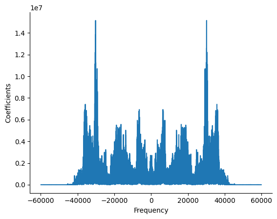

```python
FFT = fftshift(fft(a))
freqs = np.arange(a.size)

freqs = freqs - (a.size)//2

sns.lineplot(x = freqs, y = np.abs(FFT))
plt.ylabel('Coefficients')
plt.xlabel('Frequency')
sns.despine()
```

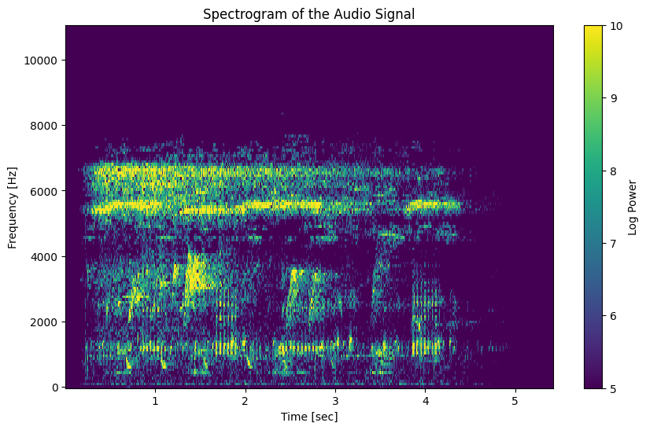

```python
f, t, Sxx = signal.spectrogram(a, s_rate)
plt.figure(figsize=(10, 6))
plt.pcolormesh(t, f, np.log(Sxx),vmin = 5,vmax = 10)
plt.ylabel('Frequency [Hz]')
plt.xlabel('Time [sec]')
plt.colorbar(label='Log Power')
plt.title('Spectrogram of the Audio Signal')
plt.show()
```

## Exercise 2 (6 marks)

The audio file contains sounds produced by different animals. Try to identify which parts of the spectrum belong to different animals. Design 3 different filters that each isolate the sound produced by 3 types of animal. Each filter should roughly conserve only the frequency range of one animal type and remove all other frequencies above and below that range. It can help to use 'plt.xlim' and 'plt.ylim' to zoom in on different parts of the spectrogram and find the correct parts of the spectrum. It can also be very useful to change 'vmin' and 'vmax' to find the animals.

After filtering the signal, listen to the results to make sure that you have roughly isolated the animal. Finally, **make one spectrogram for each filtered signal**.

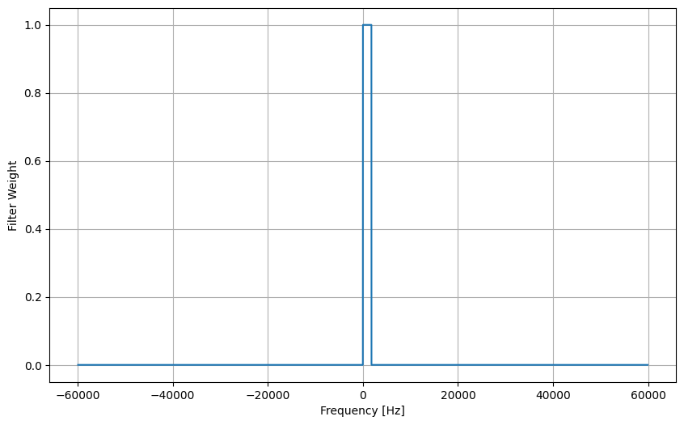

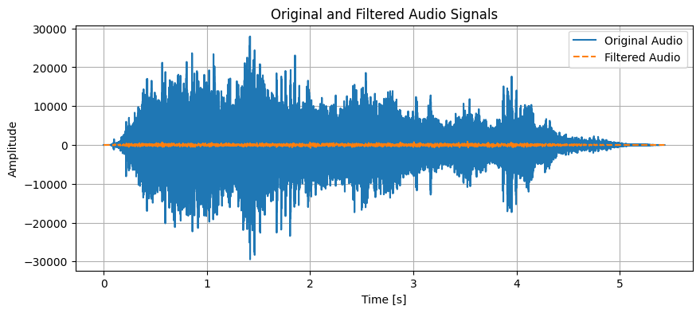

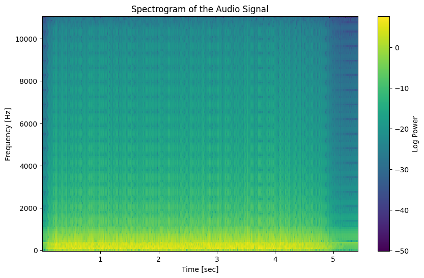

```python
minf1 = 0  # Minimum frequency in Hz
maxf1 = 1800 # Maximum frequency in Hz

# Create a filter (weights array) to isolate frequencies between minf and maxf
weights1 = np.ones(len(freqs))  # Start with an array of ones (keep all frequencies)

# Set frequencies below minf to 0 (remove lower frequencies)
weights1[freqs < minf1] = 0

# Set frequencies above maxf to 0 (remove higher frequencies)
weights1[freqs > maxf1] = 0

# Plot the filter (weights array) to ensure it's correctly applied
plt.figure(figsize=(10, 6))
plt.plot(freqs, weights1)
plt.xlabel('Frequency [Hz]')
plt.ylabel('Filter Weight')
plt.grid(True)
plt.show()

# Apply the filter to the FFT of the signal
filtered_fft = FFT * weights1

# Inverse FFT to get the filtered audio signal
filtered_audio_signal1 = np.real(np.fft.ifft(np.fft.ifftshift(filtered_fft)))

# Plot the original and filtered audio signals
plt.figure(figsize=(10, 4))
plt.plot(x1, a, label='Original Audio')
plt.plot(x1, filtered_audio_signal1, label='Filtered Audio', linestyle='--')
plt.xlabel("Time [s]")
plt.ylabel("Amplitude")
plt.title("Original and Filtered Audio Signals")
plt.legend()
plt.grid(True)
plt.show()

# Play the filtered audio (optional)
ipd.Audio(filtered_audio_signal1, rate=s_rate)
f, t, Sxx = signal.spectrogram(filtered_audio_signal1, s_rate)
plt.figure(figsize=(10, 6))
plt.pcolormesh(t, f, np.log(Sxx))
plt.ylabel('Frequency [Hz]')
plt.xlabel('Time [sec]')
plt.colorbar(label='Log Power')
plt.title('Spectrogram of the Audio Signal')
plt.show()
```

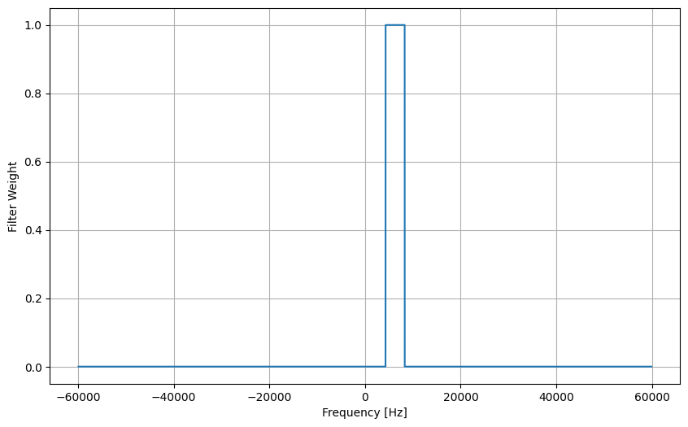

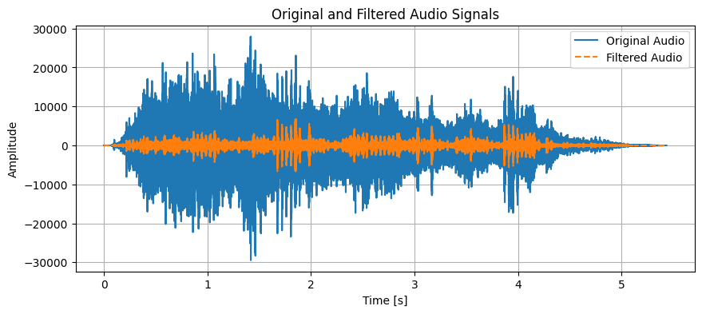

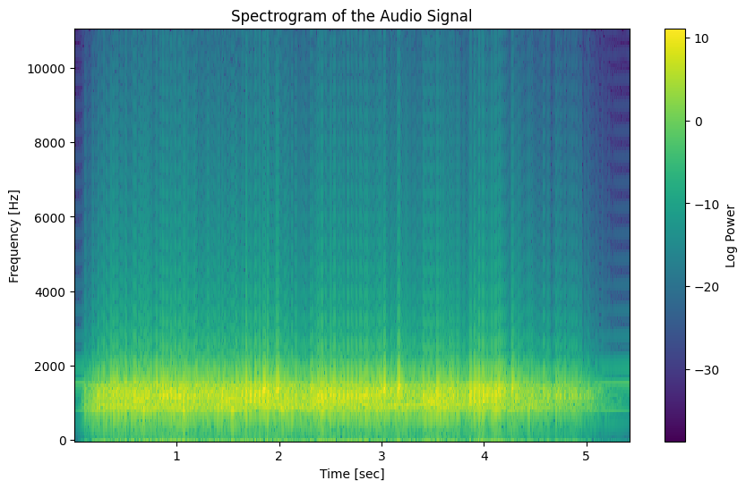

```python
minf2 = 4300  # Minimum frequency in Hz
maxf2 = 8300 # Maximum frequency in Hz

# Create a filter (weights array) to isolate frequencies between minf and maxf
weights2 = np.ones(len(freqs))  # Start with an array of ones (keep all frequencies)

# Set frequencies below minf to 0 (remove lower frequencies)
weights2[freqs < minf2] = 0

# Set frequencies above maxf to 0 (remove higher frequencies)
weights2[freqs > maxf2] = 0

# Plot the filter (weights array) to ensure it's correctly applied
plt.figure(figsize=(10, 6))
plt.plot(freqs, weights2)
plt.xlabel('Frequency [Hz]')
plt.ylabel('Filter Weight')
plt.grid(True)
plt.show()

# Apply the filter to the FFT of the signal
filtered_fft = FFT * weights2

# Inverse FFT to get the filtered audio signal
filtered_audio_signal2 = np.real(np.fft.ifft(np.fft.ifftshift(filtered_fft)))

# Plot the original and filtered audio signals
plt.figure(figsize=(10, 4))
plt.plot(x1, a, label='Original Audio')
plt.plot(x1, filtered_audio_signal2, label='Filtered Audio', linestyle='--')
plt.xlabel("Time [s]")
plt.ylabel("Amplitude")
plt.title("Original and Filtered Audio Signals")
plt.legend()
plt.grid(True)
plt.show()

# Play the filtered audio (optional)
ipd.Audio(filtered_audio_signal2, rate=s_rate)
f, t, Sxx = signal.spectrogram(filtered_audio_signal2, s_rate)
plt.figure(figsize=(10, 6))
plt.pcolormesh(t, f, np.log(Sxx))
plt.ylabel('Frequency [Hz]')
plt.xlabel('Time [sec]')
plt.colorbar(label='Log Power')
plt.title('Spectrogram of the Audio Signal')
plt.show()
```

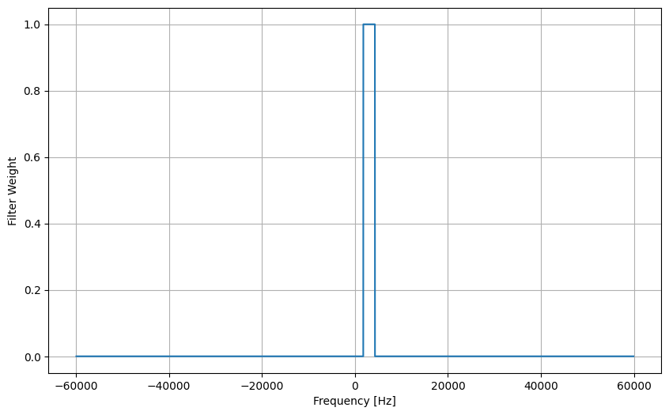

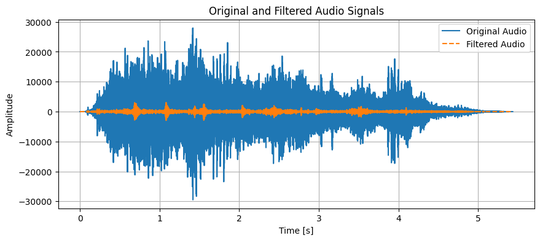

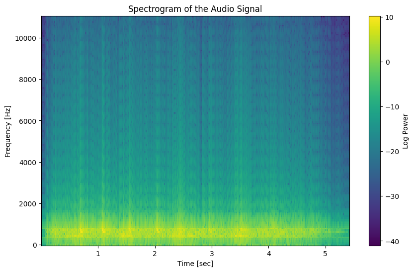

[interactive chart not shown]

```python
minf3 = 1800  # Minimum frequency in Hz
maxf3 = 4300 # Maximum frequency in Hz

# Create a filter (weights array) to isolate frequencies between minf and maxf
weights3 = np.ones(len(freqs))  # Start with an array of ones (keep all frequencies)

# Set frequencies below minf to 0 (remove lower frequencies)
weights3[freqs < minf3] = 0

# Set frequencies above maxf to 0 (remove higher frequencies)
weights3[freqs > maxf3] = 0

# Plot the filter (weights array) to ensure it's correctly applied
plt.figure(figsize=(10, 6))
plt.plot(freqs, weights3)
plt.xlabel('Frequency [Hz]')
plt.ylabel('Filter Weight')
plt.grid(True)
plt.show()

# Apply the filter to the FFT of the signal
filtered_fft = FFT * weights3

# Inverse FFT to get the filtered audio signal
filtered_audio_signal3 = np.real(np.fft.ifft(np.fft.ifftshift(filtered_fft)))

# Plot the original and filtered audio signals
plt.figure(figsize=(10, 4))
plt.plot(x1, a, label='Original Audio')
plt.plot(x1, filtered_audio_signal3, label='Filtered Audio', linestyle='--')
plt.xlabel("Time [s]")
plt.ylabel("Amplitude")
plt.title("Original and Filtered Audio Signals")
plt.legend()
plt.grid(True)
plt.show()

# Play the filtered audio (optional)

f, t, Sxx = signal.spectrogram(filtered_audio_signal3, s_rate)
plt.figure(figsize=(10, 6))
plt.pcolormesh(t, f, np.log(Sxx))
plt.ylabel('Frequency [Hz]')
plt.xlabel('Time [sec]')
plt.colorbar(label='Log Power')
plt.title('Spectrogram of the Audio Signal')
plt.show()
ipd.Audio(filtered_audio_signal3, rate=s_rate)
```

## Exercise 3 (2 marks)

So far we have used only brick wall filters that set the weight to 0 and 1 for frequencies that should be removed or retained. Use a convolution to create a filter for one of the animals that transitions more smoothly between areas of the spectrum that are removed and that are retained. Plot the **filter weights** and make a **spectrogram after filtering**.

```python
# Box Kernel for applying convolution for smoothing
windowsize = 4449
boxSize = 3337
k = np.zeros(windowsize)
k[windowsize//2 - boxSize//2 : windowsize//2 + boxSize//2 +1] = 1.0/boxSize
sns.despine()
```

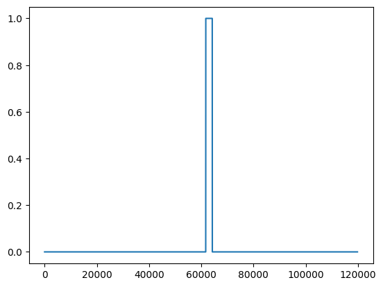

```python
#filter before convolution
plt.plot(weights3)
```

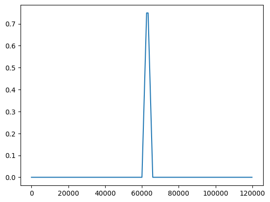

```python
result = np.convolve(weights3,k,'same')
plt.plot(result)
plt.show()
```

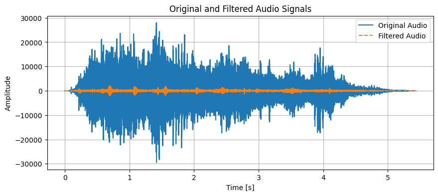

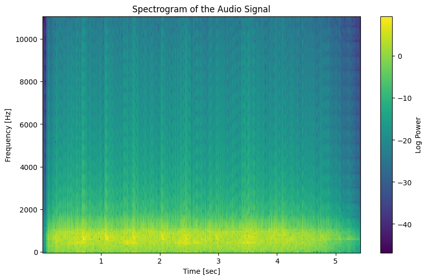

[interactive chart not shown]

```python
filtered_fft = FFT * result

# Inverse FFT to get the filtered audio signal
filtered_audio_signal4 = np.real(np.fft.ifft(np.fft.ifftshift(filtered_fft)))

# Plot the original and filtered audio signals
plt.figure(figsize=(10, 4))
plt.plot(x1, a, label='Original Audio')
plt.plot(x1, filtered_audio_signal4, label='Filtered Audio', linestyle='--')
plt.xlabel("Time [s]")
plt.ylabel("Amplitude")
plt.title("Original and Filtered Audio Signals")
plt.legend()
plt.grid(True)
plt.show()

# Play the filtered audio (optional)

f, t, Sxx = signal.spectrogram(filtered_audio_signal4, s_rate)
plt.figure(figsize=(10, 6))
plt.pcolormesh(t, f, np.log(Sxx))
plt.ylabel('Frequency [Hz]')
plt.xlabel('Time [sec]')
plt.colorbar(label='Log Power')
plt.title('Spectrogram of the Audio Signal')
plt.show()
ipd.Audio(filtered_audio_signal4, rate=s_rate)
```